# Chapter 6 - Linear Model Selection and Regularization

# Lab 3: PCR and PLS Regression

## Principal Components Regression

```r
pcr.fit=pcr(Salary~.,data=Hitters,scale=TRUE.validation="CV")
```

```
Error: unexpected '=' in "pcr.fit=pcr(Salary~.,data=Hitters,scale=TRUE.validation="
```

Setting *scale=TRUE* has the effect of *standardizing* each predictor, according to the equation seen earlier, prior to generating the principal components so that the scale on which each variable is measured will not have an effect. Setting *validation=“CV”* causes *pcr()* to perform 10-fold cross-validation for each possible value of $M$, the number of principal components used

.

```r
summary(pcr.fit)
```

```
Data:   X dimension: 263 19
    Y dimension: 263 1
Fit method: svdpc
Number of components considered: 19

VALIDATION: RMSEP
Cross-validated using 10 random segments.
       (Intercept)  1 comps  2 comps  3 comps  4 comps  5 comps  6 comps  7 comps  8 comps  9 comps  10 comps  11 comps  12 comps  13 comps
CV             452    348.9    352.2    353.5    352.8    350.1    349.1    349.6    350.9    352.9     353.8     355.0     356.2     363.5
adjCV          452    348.7    351.8    352.9    352.1    349.3    348.0    348.5    349.8    351.6     352.3     353.4     354.5     361.6
       14 comps  15 comps  16 comps  17 comps  18 comps  19 comps
CV        355.2     357.4     347.6     350.1     349.2     352.6
adjCV     352.8     355.2     345.5     347.6     346.7     349.8

TRAINING: % variance explained
        1 comps  2 comps  3 comps  4 comps  5 comps  6 comps  7 comps  8 comps  9 comps  10 comps  11 comps  12 comps  13 comps  14 comps
X         38.31    60.16    70.84    79.03    84.29    88.63    92.26    94.96    96.28     97.26     97.98     98.65     99.15     99.47
Salary    40.63    41.58    42.17    43.22    44.90    46.48    46.69    46.75    46.86     47.76     47.82     47.85     48.10     50.40
        15 comps  16 comps  17 comps  18 comps  19 comps
X          99.75     99.89     99.97     99.99    100.00
Salary     50.55     53.01     53.85     54.61     54.61
```

Note that this is the *root mean squared error*. One cal also plot the cross-validation scores using the *validationplot()* function. Using *val.type=“MSEP”* will cause the cross-validation MSE to be plotted.

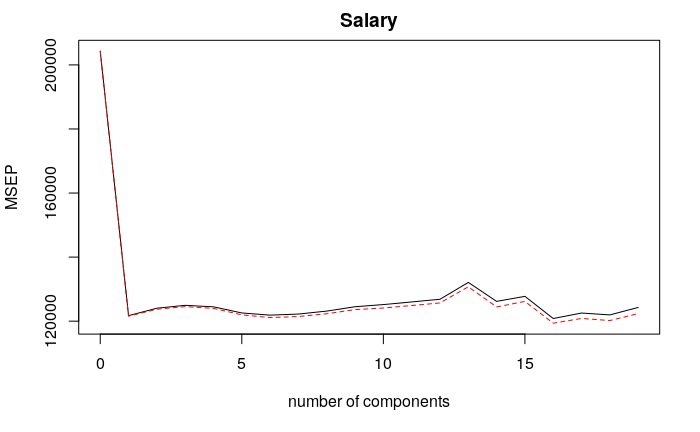

Note that the lowest MSE occurs when $M=16$, which is barely better than performing just least squares regression. However, the plot shows that using a single component in the model gives us roughly the same cross-validation error. This suggests that a model that uses just a small number of components might suffice.

We now perform PCR on the training data and evaluate its test set performance

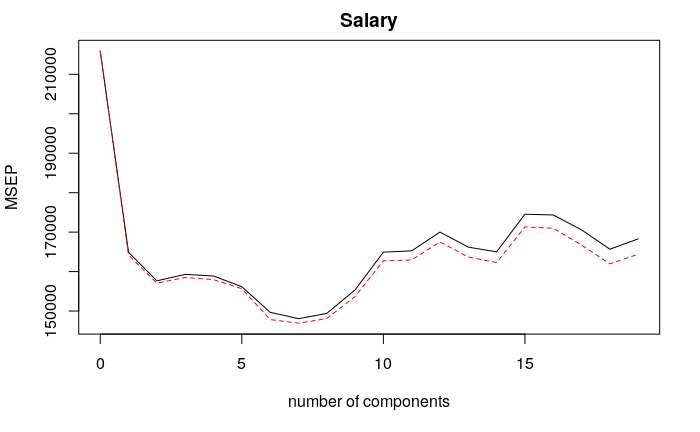

```r
set.seed(1)
pcr.fit=pcr(Salary~.,data=Hitters,subset=train,scale=TRUE,validation="CV")
validationplot(pcr.fit,val.type = "MSEP")
```

We compute the test MSE as follows.

```r
pcr.pred=predict(pcr.fit,x[test,],ncomp=7) #validation plot indicates lowest MSE with 7 components
mean((pcr.pred-y.test)^2)
```

```
[1] 96556.22
```

This test set MSE is competitive with the results obtained using ridge regression and the lasso. However, as a result of the way PCR is implemented, the final model is more difficult to interpret because it does not perform ny kind of variable selection or even directly produce coefficient estimates.

Finally we fit PCR on the full data set.

```r
summary(pcr.fit)
```

[output not shown]

## Partial least squares

```r
set.seed(1)
pls.fit=plsr(Salary~.,data=Hitters,subset=train,scale=TRUE,validation="CV")
summary(pls.fit)
```

```
Data:   X dimension: 131 19
    Y dimension: 131 1
Fit method: kernelpls
Number of components considered: 19

VALIDATION: RMSEP
Cross-validated using 10 random segments.
       (Intercept)  1 comps  2 comps  3 comps  4 comps  5 comps  6 comps  7 comps  8 comps  9 comps  10 comps  11 comps  12 comps  13 comps
CV           464.6    394.2    391.5    393.1    395.0    415.0    424.0    424.5    415.8    404.6     407.1     412.0     414.4     410.3
adjCV        464.6    393.4    390.2    391.1    392.9    411.5    418.8    418.9    411.4    400.7     402.2     407.2     409.3     405.6
       14 comps  15 comps  16 comps  17 comps  18 comps  19 comps
CV        406.2     408.6     410.5     408.8     407.8     410.2
adjCV     401.8     403.9     405.6     404.1     403.2     405.5

TRAINING: % variance explained
        1 comps  2 comps  3 comps  4 comps  5 comps  6 comps  7 comps  8 comps  9 comps  10 comps  11 comps  12 comps  13 comps  14 comps
X         38.12    53.46    66.05    74.49    79.33    84.56    87.09    90.74    92.55     93.94     97.23     97.88     98.35     98.85
Salary    33.58    38.96    41.57    42.43    44.04    45.59    47.05    47.53    48.42     49.68     50.04     50.54     50.78     50.92
        15 comps  16 comps  17 comps  18 comps  19 comps
X          99.11     99.43     99.78     99.99    100.00
Salary     51.04     51.11     51.15     51.16     51.18
```

```r
pls.pred=predict(pls.fit,x[test,],ncomp=2) #lowest MSE with 2 components
mean((pls.pred-y.test)^2)
```

```
[1] 101417.5
```

```r
pls.fit=plsr(Salary~.,data=Hitters,scale=TRUE,ncomp=2)
summary(pls.fit)
```

```
Data:   X dimension: 263 19
    Y dimension: 263 1
Fit method: kernelpls
Number of components considered: 2
TRAINING: % variance explained
        1 comps  2 comps
X         38.08    51.03
Salary    43.05    46.40
```

Notice that the percentage of variance in **Salary** that the two-component PLS fit expalins, 46.40%, is almost as much as that explained using the final seven-component model PCR fit, 46.69%. This is because PCR only attempts to maximize the amount of variance explained in the predictrs, while PLS searches for directions that explain variance in both the predictors and the response.